# Deskriptive Regressionsanalyse

## 2.3 Deskriptive Regression

### 2.3.1 R als Taschenrechner

Im Rahmen der **deskriptiven** Regressionsanalyse ist bei Nutzung von Base-R-Funktionen im Rahmen der folgenden Berechnungen ggf. die bereits bekannte *Korrektur der Freiheitsgrade* vorzunehmen: teilen durch n und nicht durch (n-1). Wir werden jedoch sehen, dass dies für die Berechnung der Regressionskoeffizienten letztlich nicht erforderlich ist (s.u.).

```r
## Deskriptive Regressionsanalyse ------
### R als Taschenrechner -----
# n ermitteln
n <- tbl_marketing %>%
            summarise(n=n()) %>%
            pull()
# Varianz-Kovarianz-Matrix
cov(tbl_marketing)*(n-1)/n # mit Korrektur der Freiheitsgrade - Varianz-Kovarianz-Matrix der Grundgesamtheit!
```

```
##         Werbung Umsatz
## Werbung   6.250  7.625
## Umsatz    7.625  9.750
```

```r
var(tbl_marketing)*(n-1)/n # mit Korrektur der Freiheitsgrade
```

```
##         Werbung Umsatz
## Werbung   6.250  7.625
## Umsatz    7.625  9.750
```

```r
cov_matrix<-cov(tbl_marketing)*(n-1)/n
# Regressionskoeffizienten berechnen
b_2<-cov_matrix[1,2]/cov_matrix[1,1]
b_2
```

```
## [1] 1.22
```

```r
b_1<-mean(tbl_marketing$Umsatz)-b_2*mean(tbl_marketing$Werbung)
b_1
```

```
## [1] -0.54
```

### 2.3.2 Nutzung der `lm()`-Funktion (Base R)

In Base R kann die Regressionsgerade direkt mit Hilfer der Funktion lm() für *linear model* berechnet werden. Diese Funktion erzeugt ein Objekt, das wir unter dem Namen reg_model speichern. In der lm()-Funktion müssen wir neben den Daten auch die Regressionsgleichung spezifizieren: * Dabei erfolgt die Eingabe des Regressanden (der abhängigen Variable) vor einem Tilde-Zeichen (~). * Nach diesem Zeichen wird im vorliegenden Fall einer **linearen Einfachregresion** der Regressor eingegeben. Im Fall der sog. multiplen Regression können auch mehrere Regressoren additiv verknüpft werden.

```r
### lm()-Funktion ------
reg_model <- lm(Umsatz ~ Werbung, data = tbl_marketing)
class(reg_model)
```

```
## [1] "lm"
```

```r
reg_model
```

```
##
## Call:
## lm(formula = Umsatz ~ Werbung, data = tbl_marketing)
##
## Coefficients:
## (Intercept)      Werbung
##       -0.54         1.22
```

```r
b_1<-reg_model$coefficients[1]
b_2<-reg_model$coefficients[2]
```

Die `lm()`-Funktion erzeugt also ein Objekt aus der Klasse *lm*, das sämtliche Informationen zur durchgeführten Regression enthält. Der Aufruf des Objekts *reg_model* führt zur Ausgabe der den Berechnungen zugrundeliegenden Regressionsgleichung und den Koeffizienten. Der Achsenabschnitt der berechneten Regressionsgerade ist im vorliegenden Fall mit $\beta_1=$-0.54 negativ und entzieht sich somit einer sinnvollen inhaltlichen Interpretation: ein negativer Umsatz ist per definition ausgeschlossen.

Obs! Die mit der `lm()`-Funktion ermittelten Koeffizienten entsprechen den oben mit R als Taschenrechner berechneten Werten. Eine Korrektur der Freiheitsgrade ist nicht notwendig, weil die Berechnung des Steigungskoeffizienten als Verhältnis von Kovarianz und Varianz erfolgt.

### 2.3.3 Regression vs. Korrelation (Teil 1)

Im Fall der linearen Einfachregression können wir den Regressionskoeffizienten

$$\beta_2=\frac{s_{UW}}{s_W^2}$$

durch Umformung in den Pearson-Korrelationskoeffizienten überführen:

$$\beta_2\cdot\frac{s_W}{s_U}=r_{UW}$$

```r
### Variante summarise()-Funktion ----
tbl_marketing %>%
          summarise(b1=b_2*sd(Werbung)/sd(Umsatz))
```

```
## # A tibble: 1 × 1
##      b1
##   <dbl>
## 1 0.977
```

Dies entspricht unserem oben mit der `correlate()`-Funktion ermittelten Ergebnis für den Korrelationskoeffizienten.

### 2.3.4 Datenvisualisierung (Teil 2)

### 2.3.5 Plot mit Regressionsgerade

In das obige Streudiagramm können wir die eben bestimmte Regressionsgerade unkompliziert einzeichnen, indem wir einen Layer hinzufügen. Im **ggplot2**-Paket kann der zusätzliche Layer mit der `geom_smooth()`-Funktion erzeugt werden. Weil wir die Regressionsgerade oben mit der Methode der kleinsten Quadrate bestimmt haben, wählen wir analog zur Base-R-Funktion `lm()` die Option `method="lm"`. Standardmäßig wird dann in ggplot ein sog. Konfidenzintervall eingezeichnet. Da wir im Fall der empirischen Regression allerdings die Daten als Grundgesamtheit behandeln, wählen wir die Darstellung ohne Konfidenzintervall. Dies wird durch die Option `se=FALSE` umgesetzt, wobei *se* für standard error (Standardfehler) steht. Hierzu mehr, wenn wir die stochastische Regressionsanalyse behandeln.

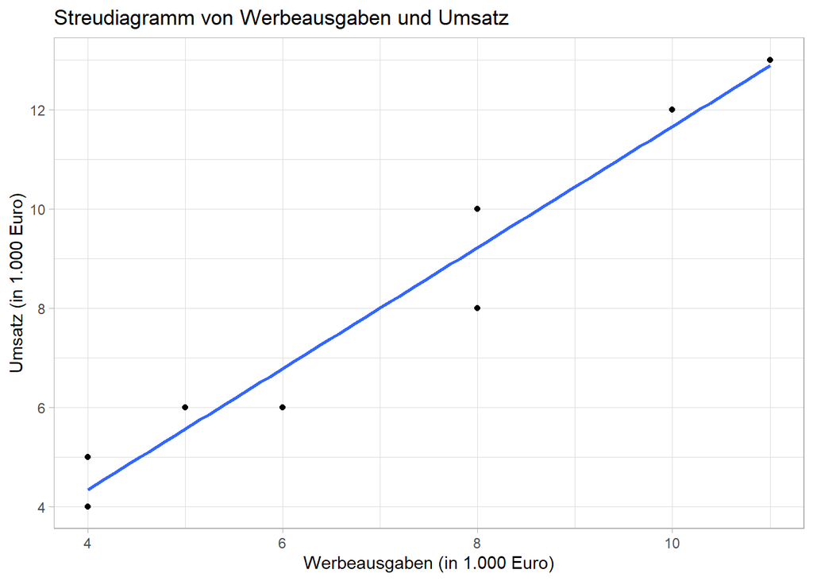

### 2.3.6 Plot mit Residuen

Die Regressionsgerade wird mit der Methode der kleinsten Quadrate “gefittet”. Dies bedeutet, dass die Gerade in die Punktwolke gelegt wird, die mit der kleinstmöglichen Summe der quadrierten Residuen verbunden ist. Residuen sind dabei als Differenz aus beobachtetem und vorhergesagtem Wert (bzw. bedingtem Mittelwert) definiert.

Um dies grafisch darzustellen müssen wir das bisher verwendete ggplot-Objekt neu definieren. Dieses wurde mit den Daten des tibble-Objekts tbl_marketing erzeugt. Dieses tibble-Objekt enthält jedoch nur die Angaben zu Werbung und Umsatz, nicht aber zu den bedingten Mittelwerten und Residuen. Zur Erweiterung unseres ursprünglichen tibble-Objekts nutzen wir das mit der `lm()`-Funktion definierte Objekt `reg_model` mit den Angaben zu unserem Regressionsmodell. Die bedingten Mittelwerte und die Residuen können aus diesem Objekt mit den Funktionen `predict()` und `residuals()` ermittelt werden.

```r
### Plot mit Residuen -----
tbl_marketing <- tbl_marketing %>%
                        mutate(vorhersage = predict(reg_model),
                               residuum = residuals(reg_model))
tbl_marketing
```

```
## # A tibble: 8 × 4
##   Werbung Umsatz vorhersage residuum
##     <dbl>  <dbl>      <dbl>    <dbl>
## 1       4      4       4.34   -0.340
## 2       4      5       4.34    0.66
## 3       5      6       5.56    0.440
## 4       6      6       6.78   -0.780
## 5       8      8       9.22   -1.22
## 6       8     10       9.22    0.780
## 7      10     12      11.7     0.340
## 8      11     13      12.9     0.120
```

$$\hat{u}_1=\beta_1+\beta_2\cdot w_1$$

```r
### Ermittlung u_dach ----
u_hat <- tbl_marketing %>%
                mutate(u_hat=b_1+b_2*Werbung) %>%
                pull(u_hat)
u_hat[1]
```

```
## [1] 4.34
```

Der durchschnittliche Umsatz bei Werbeausgaben in Höhe von 4.000€ beträgt somit 4340€. Tatsächlich lag der Umsatz in der ersten Zeile aber lediglich bei 4.000€. Die Differenz von -340€ zeigt sich im negativen Residuum von $e_1=$ -0.34. Im Unterschied zu $e_1$ ist $e_2$ mit 0.66 positiv, weil der tatsächliche Umsatz (5000€) um 660 € über dem bedingten Mittelwert von 4340€ liegt.

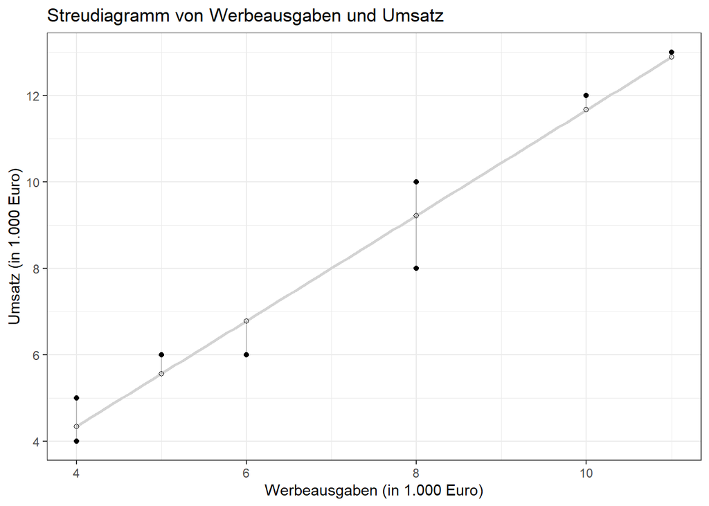

Für die Residuen einer KQ-Regression mit Interzept gilt:

- Die Summe der Residuen ist Null.
- Damit ist auch das arithmetische Mittel der Residuen Null (Erwartungstreue).
- Die Varianz der Residuen ist minimal (Effizienzeigenschaft)

### 2.3.7 Ausblick: Regressionsdiagnostik

Im (mit der `lm()`-Funktion erzeugten) Objekt `reg_model` werden wichtige Informationen zur Regressionsdiagnostik gespeichert, die benötigt werden, wenn das Regressionsmodell auf Basis einer Stichprobe “geschätzt” wurde und die Ergebnisse auf die Grundgesamtheit übertragen werden sollen (vgl. induktive Statistik!). Damit eine Verallgemeinerung von der Stichprobe auf die Grundgesamtheit erfolgen kann, müssen vier wesentliche Annahmen erfüllt sein, die auch grafisch überprüft werden können. Die dazu notwendigen Diagramme können mit der `autoplot()`-Funktion aus dem **ggfortify**-Paket als **ggplots** erzeugt werden.[^2] Die Interpretation dieser Diagramme wird erst in der induktiven Statistik relevant und daher hier nicht weiter thematisiert.

```r
### Ausblick Regressionsdiagnostik -----
#install.packages("ggfortify")
####  ggfortify package ----
library(ggfortify)
```

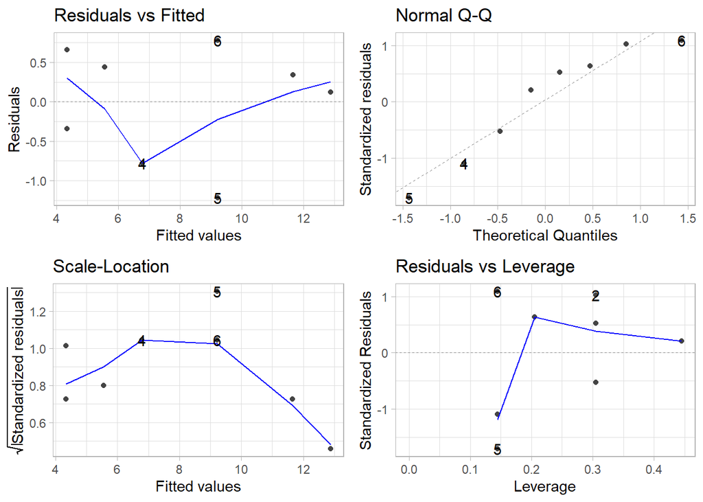

```r
#### Plot erzeugen ----
autoplot(reg_model) + theme_light()
```

```r
#### Base R -----
#par(mfrow = c(2,2)) # Der Befehl erzeugt das 2x2-Gitter
#plot(reg_model)
```

### 2.3.8 Bestimmtheitsmaß

Es ist naheliegend, dass die Aussagekraft des Regressionsmodells umso größer ist, je näher die Beobachtungen im Streudiagramm an der Regressionsgeraden liegen bzw. je geringer die Werte der Residuen sind. Dabei wissen wir bereits, dass die KQ-Residuen die Eigenschaft der minimalen Varianz besitzen. Diese Varianz der Residuen ist ein Maß für die Streuung der Daten (in unserem Fall des Umsatzes), der nicht durch das Regressionsmodell erklärt werden kann. Erklärt wird nur die Streuung, die sich aus dem Unterschied von bedingtem und unbedingtem Mittelwert ergibt.

Als Maß für die Aussagekraft des Regressionsmodells (die **Goodness of Fit**) dient das sog. Bestimmtheitsmaß $R^2$, das sich als Anteil von erklärter Streuung (ESS - Explained Sum Squared) an der Gesamtstreuung (TSS - Total Sum Squared) ergibt:

```r
## Goodness of Fit -----
### Gemäß Definition -----
SSQ<-tbl_marketing %>%
        summarise(TSS=sum((Umsatz-mean(Umsatz))^2),ESS=sum(residuum^2))
R_sq<-1-SSQ$ESS/SSQ$TSS
R_sq
```

```
## [1] 0.9541026
```

Im Fall der einfachen linearen Regression (**und nur in diesem Fall!**) entspricht das Bestimmtheitsmaß dem quadrierten Pearson-Korrelationsquotienten:

$$R^2=r_{x,y}^2$$

```r
### Sonderfall Einfachregression ------
r_p^2
```

```
##     Werbung
## 1 0.9541026
```

In Fall unserer Analyse bedeutet ein Bestimmtheitsmaß $R^2=$ 0.9541, dass 95.41 % der Gesamtstreuung durch das Regressionsmodell erklärt werden.

## 2.4 Regression vs. Korrelation (Teil 2)

Korrelationen zwischen $x$ und $y$ in allen 4 Teilmengen quasi identisch.

```r
anscombe_tidy %>%
  group_by(set) %>%
  summarise(cor(x,y))
```

```
## # A tibble: 4 × 2
##   set   `cor(x, y)`
##   <chr>       <dbl>
## 1 I           0.816
## 2 II          0.816
## 3 III         0.816
## 4 IV          0.817
```

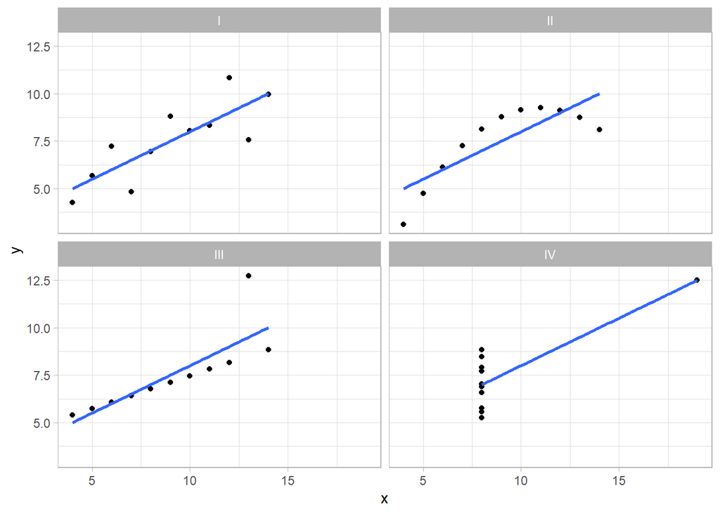

## 2.5 Regression mit dem moderndive-Paket

Die `lm()`-Funktion erzeugt wie o.a. ein Objekt der Klasse *lm*, die bei der Verwendung mit Pipes zu Problemen führen können. Das Paket **moderndive** bietet einige Wrapper-Funktionen, die mit tibbles arbeiten und so auch in *Pipes* verwendet werden können (vgl. Ismay and Kim (2023)).

Als Alternative zur `correlate()`-Funktion bietet das **moderndive**-Paket die `get_correlation()`-Funktion. Die Eingabe erfolgt wie im Fall der `lm()`-Funktion, sodass eine einheitliche Syntax für Korrelations- und Regressionsanalyse möglich wird.

```r
# Regression mit moderndive-Paket ------
library(moderndive)
tbl_marketing %>%
    get_correlation(formula = Umsatz ~ Werbung)
```

```
## # A tibble: 1 × 1
##     cor
##   <dbl>
## 1 0.977
```

Oben haben wir das Objekt `tbl_marketing` mit den vorhergesagten Werten und Residuen ergänzt, indem wir die Base-R-Funktionen `predict()` und `residuals()` in einer `mutate()`-Funktion genutzt haben. Hier bietet die Funktion `get_regression_points()` im moderndive-Paket einen deutlich komfortableren Weg, um die vorhergesagten Werte und Residuen zu ermitteln und in einem tibble-Objekt zu speichern.

```r
moderndive::get_regression_points(reg_model)
```

```
## # A tibble: 8 × 5
##      ID Umsatz Werbung Umsatz_hat residual
##   <int>  <dbl>   <dbl>      <dbl>    <dbl>
## 1     1      4       4       4.34    -0.34
## 2     2      5       4       4.34     0.66
## 3     3      6       5       5.56     0.44
## 4     4      6       6       6.78    -0.78
## 5     5      8       8       9.22    -1.22
## 6     6     10       8       9.22     0.78
## 7     7     12      10      11.7      0.34
## 8     8     13      11      12.9      0.12
```

Weitere praktische Funktionen des **moderndive**-Pakets werden wir vor allem im Rahmen der stochastischen Regressionsanalyse nutzen.

# 3 Explorative Datenanalyse

Beipsiel [Horror Movies & Profit](https://stephenturner.github.io/workshops/r-refresher-tidy-eda.html)

# Quellenverzeichnis

Ismay, Chester, and Albert Y. Kim. 2023. *Statistical Inference via Data Science. A ModernDive into R and the Tidyverse*. Boca Raton: CRC Press / Taylor & Francis Group. https://moderndive.com/.

Stocker, Herbert. 2023. “Grundlagen Der Deskriptiven Regressionsanalyse - OLS Mechanik.” In *Methoden Der Empirischen Wirtschaftsforschung. Vorlesungsmanuskript*. Universität Innsbruck. https://www.uibk.ac.at/econometrics/einf/kap02_ols.pdf.

[^1]: Umgekehrt $\hat{x}=h(y)$ als Regression von X auf Y (x-y-Regression).
[^2]: Die Informationen können auch direkt in Base R geplottet werden. Die Eingabe von `plot(reg_model)` erzeugt eine Reihe von Abbildungen. Bei Eingabe in der R-Console erscheint die Aufforderung zur Betätigung der Enter-Tase, um von einer Abbildung zur nächsten zu gelangen. Die Abbildungen können auch auf einmal angezeigt werden, indem mit `par(mfrow = c(2,2))` ein Gitter (sog. grid) mit 4 Feldern (2x2 grid) erzeugt wird.